# Demo 11 | Regression Fundamentals

Peter Kedron¹

2026-11-16

¹ Department of Geography, University of California Santa Barbara

Version 1.0 | First Created 2026-11-07 | Updated 2026-11-08

# 1. Introduction

Maps of the 2024 presidential vote show strong geographic patterns across the United States. Counties with similar Democratic vote shares tend to sit near one another, and the national map divides sharply between cities and the countryside. Describing those patterns tells us *where* the vote differs, and may offer clues about *why* a county votes the way it does. The question of why this election turned out as it did can be explored further by trying to connect the presidential vote (response variable) to the characteristics of the places where those votes occured (predictor variables).

**Regression** is that statistical technique that can be used to make this connection. A regression model links a **response variable**, such as a county’s 2024 Democratic share, to county characteristics, such as education, industry, and population density, plus an error term for everything the model leaves out. Fitted to data, the model estimates how strongly each characteristic is associated with the response variable, holding the others constant, and how much of the variation in the response variable the characteristics collectively account for.

This demonstration fits a regression model to the 2024 presidential vote in the counties of Michigan, Wisconsin, and Minnesota. The goal is to understand whether characteristics of those counties are strongly associated with the presidential vote. Those associations can be the start of building an explanation of why the election had the result it did in this Midwest region.

During the demonstration, we will:

- **Choose and screen predictors** from hypotheses, with a correlation matrix and variance inflation factors (VIFs).
- **Fit an ordinary least squares (OLS) regression** of the 2024 Democratic share on those predictors.
- **Check the assumptions** of the model with residual plots, Q-Q plots, leverage, and Cook’s distance.
- **Read the model’s fit and interpret its coefficients**, paying attention to units, logged predictors, and what “holding the other predictors constant” means.

One assumption, that the errors are independent of one another, is set aside within this demonstration. Checking that assumption means putting the residuals back on the map, which is the starting point for spatial regression.

**Keywords:** linear regression, ordinary least squares, coefficient interpretation, multicollinearity, regression diagnostics

# 2. Study Region and Data

## 2.1 Study Region

Our study region is the Upper Midwest: the 242 counties of Michigan, Wisconsin, and Minnesota. These are the **core** counties, the ones we describe, model, and report on.

The **response variable** throughout is the **Democratic share (`dem_share24`)**: Harris’s votes divided by the votes for Harris and Trump, times 100. Defined this way, it ranges from 0 to 100 percent and excludes votes for other candidates.

```r
# Load the county polygons (core and guard) and the background layer
study_area <- st_read(data_file, layer = "counties", quiet = TRUE) %>%
  mutate(name = paste0(county, ", ", state_abb),
         role = factor(role, levels = c("core", "guard")))
background <- st_read(data_file, layer = "background", quiet = TRUE)

# The core study region, used in every table and model until the end of the demonstration
midwest <- study_area %>% filter(role == "core")

# The response variable
response <- "dem_share24"
```

**Figure 1** maps the democratic vote share. Across the core counties, the Democratic share ranges from 21.6 percent in Morrison County, MN to 81 percent in Menominee County, WI. Only 31 of the 242 counties gave Harris a majority of the two-party vote. Most of the highest shares are in metropolitan and college-town counties: Hennepin and Ramsey (Minneapolis–Saint Paul), Dane (Madison), Milwaukee, Wayne (Detroit), Washtenaw (Ann Arbor), and Ingham (Lansing). A few rural northern counties also vote strongly Democratic, among them Menominee in Wisconsin, which is coterminous with the Menominee Indian Reservation, and Cook in Minnesota’s Arrowhead. Overall, most of the region’s land area is rural and votes well below 50 percent democratic in this election.

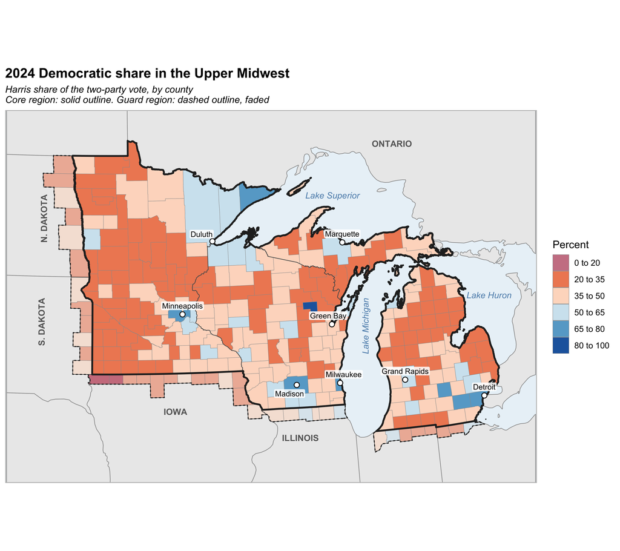

Figure 1: The response variable, the 2024 Democratic share of the two-party vote, by county, in six classes: red below 50 percent and blue above. The 242 core counties of Michigan, Wisconsin, and Minnesota are inside the solid outline; the 39 guard counties are faded, inside the dashed outline. State boundaries and major cities are shown for reference.

## 2.2 Data

The data are a regional extract of a national county-level file that joins 2024 presidential election results, compiled from the MIT Election Data and Science Lab, to county characteristics from federal and research sources and the American Community Survey (2019–2023). Two files are provided in this folder:

- **Upper Midwest counties (`midwest-election-2024.gpkg`):** the 281 counties of the study region (242 core and 39 guard), projected to NAD83 / Conus Albers (EPSG:5070, meters). The file has two layers:
  - `counties`: one polygon per county, with its FIPS code (`fips`), state (`state_abb`), name (`county`), and role in the study region (`role`: `core` or `guard`), the response variable, and the county characteristics listed in Table 1.
  - `background`: the surrounding U.S. states and Canadian provinces (Natural Earth, 1:50 million), for the maps only.
- **Codebook (`midwest-election-2024-variables.csv`):** the description, units, source, and motivating research for every variable in the `counties` layer, taken from the codebook of the national file.

**Table 1** lists the response variable and the candidate predictors. The predictors cover six themes that research on county voting patterns has linked to partisanship: race and ethnicity, education, age, settlement, economic conditions, and the cost of living. Several describe the region’s working-class, industrial, and economic profile, which has been central to discussions of how the Upper Midwest votes.

```r
# Load the codebook
codebook <- read.csv(file.path("midwest-election-2024-variables.csv"))

# The candidate predictors, grouped by theme
themes <- c(hispanic_pct = "Race and ethnicity", black_pct = "Race and ethnicity", native_pct = "Race and ethnicity",
            bachelors_pct = "Education", white_nocollege_pct = "Education",
            age18to29_pct = "Age", median_age = "Age",
            rural_pct = "Settlement", log_pop_density = "Settlement",
            poverty_pct = "Economic conditions", manuf_pct = "Economic conditions",
            unemp_change = "Economic conditions", median_hh_inc = "Economic conditions",
            cost_chg_total = "Cost of living")
candidates <- names(themes)

# Short labels for tables and figures
var_labels <- c(dem_share24 = "Democratic share", hispanic_pct = "Hispanic share",
                black_pct = "Black share", native_pct = "Native American share",
                bachelors_pct = "Bachelor's degree share", poverty_pct = "Poverty rate",
                age18to29_pct = "Share aged 18 to 29", rural_pct = "Rural share",
                cost_chg_total = "Cost of living change", white_nocollege_pct = "White non-college share",
                manuf_pct = "Manufacturing share", log_pop_density = "Log population density",
                median_age = "Median age", unemp_change = "Unemployment change",
                median_hh_inc = "Median household income")
```

| Group | Variable | Description | Units |
| --- | --- | --- | --- |
| Response variable | `dem_share24` | Democratic share of the two-party vote: Harris / (Harris + Trump) × 100 | % |
| Race and ethnicity | `hispanic_pct` | Hispanic or Latino share of population (any race) | % |
| Race and ethnicity | `black_pct` | Non-Hispanic Black share of population | % |
| Race and ethnicity | `native_pct` | Non-Hispanic American Indian and Alaska Native share of population | % |
| Education | `bachelors_pct` | Share of adults 25+ with a bachelor’s degree or higher | % |
| Education | `white_nocollege_pct` | Non-Hispanic white adults 25+ without a bachelor’s degree as a share of all adults 25+ | % |
| Age | `age18to29_pct` | Share of population aged 18–29 | % |
| Age | `median_age` | Median age | years |
| Settlement | `rural_pct` | Share of population living in rural areas (2020 Census definition) | % |
| Settlement | `log_pop_density` | Natural log of population density | log persons/km² |
| Economic conditions | `poverty_pct` | Share of people with income below the poverty line | % |
| Economic conditions | `manuf_pct` | Share of civilian employed workers 16+ in manufacturing | % |
| Economic conditions | `unemp_change` | Change in unemployment rate, 2020 to 2023 annual averages (2020 includes the COVID-19 spike) | percentage points |
| Economic conditions | `median_hh_inc` | Median household income | 2023 dollars |
| Cost of living | `cost_chg_total` | Percent change in the total family budget, 2023 to 2024 | % |

Table 1: The response variable and the candidate predictors, with their descriptions and units from the codebook.

**Table 2** summarizes the response variable and the candidate predictors for the core counties. Two features of the table matter for what follows. First, the variables are measured on very different scales, from percentages to years, to dollars, so a coefficient’s size depends on its predictor’s units and cannot be compared directly across predictors. Second, several predictors are strongly skewed, with most counties near the minimum and a few far above it. The racial and ethnic shares are the most extreme: the native american share has a skewness of 9.7, because a few counties, such as those containing reservations, have shares many times the regional median. Population density is skewed in the same way (skewness 5.9), which is why the file provides it on the log scale (`log_pop_density`, skewness 0.6).

| Variable | Units | Mean | SD | Min | Median | Max |
| --- | --- | --- | --- | --- | --- | --- |
| Democratic share | % | 38.70 | 10.31 | 21.56 | 35.58 | 81.05 |
| Hispanic share | % | 4.69 | 3.88 | 0.58 | 3.57 | 33.14 |
| Black share | % | 2.43 | 4.19 | 0.00 | 0.88 | 36.98 |
| Native American share | % | 1.64 | 5.98 | 0.00 | 0.30 | 78.41 |
| Bachelor’s degree share | % | 25.55 | 8.75 | 12.49 | 23.25 | 58.13 |
| White non-college share | % | 65.76 | 11.45 | 11.74 | 69.06 | 82.77 |
| Share aged 18 to 29 | % | 13.47 | 3.69 | 8.36 | 12.66 | 32.49 |
| Median age | years | 43.74 | 5.67 | 29.80 | 42.80 | 59.70 |
| Rural share | % | 65.71 | 29.87 | 0.02 | 67.36 | 100.00 |
| Log population density | log persons/km² | 3.01 | 1.36 | 0.12 | 2.86 | 7.30 |
| Poverty rate | % | 11.24 | 3.38 | 4.12 | 10.86 | 23.16 |
| Manufacturing share | % | 16.59 | 5.83 | 2.51 | 16.20 | 39.19 |
| Unemployment change | percentage points | -3.68 | 1.47 | -9.60 | -3.40 | -0.20 |
| Median household income | 2023 dollars | 70,626.60 | 12,595.67 | 47,777.00 | 69,582.50 | 123,144.00 |
| Cost of living change | % | 4.20 | 4.40 | -8.56 | 3.96 | 21.55 |

Table 2: Summary statistics for the response variable and the candidate predictors in the 242 core counties of Michigan, Wisconsin, and Minnesota (guard counties excluded).

# 3. Specification

**Specification** is the set of decisions that turns a question into a model: which predictors are included in the model, in what form, and how we judge whether the fitted model can be trusted. This section works through those decisions in the order an analyst typically makes them:

1. **Choose the predictors** from hypotheses, before looking at any results (3.1).
2. **Screen them** for their relationships with the response variable and with one another (3.2), and for multicollinearity (3.3).
3. **Fit the model** by ordinary least squares (3.4).
4. **Check the assumptions** the model rests on (3.5).
5. **Assess the model fit** (3.6).

Interpreting the coefficients follows in Section 4. The assumptions come before interpretation because the standard errors and p-values that we use to interpret coefficients are only as good as the assumptions behind them.

## 3.1 Choosing Predictors

**Table 1** offers 14 candidate predictors for the election model. We could enter them all, or let the data choose among them, but both approaches invite **fishing**. Fish, or p-hacking, occurs when an analyst tries predictors until something is significant, and then telling a story to fit that result. With enough candidates, some will look important by chance alone.

Instead, each predictor should answer a hypothesis that we can state, with an expected sign, *before* fitting the model. We use five predictors, each tied to an explanation of how the Upper Midwest votes (**Table 3**).

| Predictor | Units | Hypothesis | Expected sign | Form |
| --- | --- | --- | --- | --- |
| White non-college share (`white_nocollege_pct`) | % | The education divide among white voters is the sharpest political fault line in the region (Sides et al. 2018). | Negative | Untransformed |
| Manufacturing share (`manuf_pct`) | % | Places exposed to deindustrialization and trade competition shifted toward republican candidates (Autor et al. 2020). | Negative | Untransformed |
| Log population density (`log_pop_density`) | log persons/km² | The urban–rural divide is among the strongest predictors of partisanship (Scala & Johnson 2017). | Positive | Natural log |
| Median age (`median_age`) | years | Older places lean Republican (Goetz et al. 2019). | Negative | Untransformed |
| Unemployment change (`unemp_change`) | percentage points | Voters punish the incumbent party when the economy worsens (Hummel & Rothschild 2014). | Negative | Untransformed |

Table 3: The five predictors, the hypothesis behind each, the sign we expect before fitting the model, and the form in which each enters.

Three of the choices in Table 3 deserve explanation.

- **Population density enters on the log scale.** Raw density is extremely right-skewed (Table 2): a few urban counties are hundreds of times denser than most rural counties. Left untransformed, those few counties would dominate the fit. Logging pulls in the long tail and changes what the coefficient describes: a one-unit change in $\ln(\text{density})$ is a *proportional* change in density, so going from 10 to 20 persons per km² counts the same as going from 1,000 to 2,000.
- **Unemployment change has an unusual baseline.** It measures the change from 2020 to 2023, and 2020 includes the COVID-19 spike, so nearly every county has a *negative* value (unemployment fell). A higher value therefore means a *smaller* recovery, a weaker economy. If voters punished the incumbent Democrats for a weak economy, the expected sign is negative.
- **Some candidates are left out on purpose.** The bachelor’s degree share and the white non-college share overlap by construction, so we use only one. The racial and ethnic shares are extremely skewed in this region (Table 2) and describe a few counties far more than the region as a whole.

Written out, the model is
$$\begin{aligned}
\text{Democratic share}_i = {} & \beta_0 + \beta_1\,\text{White non-college}_i + \beta_2\,\text{Manufacturing}_i + \beta_3\,\ln(\text{Density}_i) \\
& + \beta_4\,\text{Median age}_i + \beta_5\,\text{Unemployment change}_i + \varepsilon_i
\end{aligned}$$
where $i$ indexes the 242 core counties and $\varepsilon_i$ is the error, everything about county $i$ that the five predictors do not capture.

## 3.2 Correlation Screening

Before fitting anything, a **correlation matrix** gives a first look at the data. The correlation matrix can be used to answer two question at the same time:

- **Predictor ↔︎ response variable:** which predictors are associated with the Democratic share on their own?
- **Predictor ↔︎ predictor:** which predictors are associated with one another, and potentially carry overlapping information?

The bottom row of Figure 2 (Democratic share) answers the first question, and the rest of the matrix answers the second.

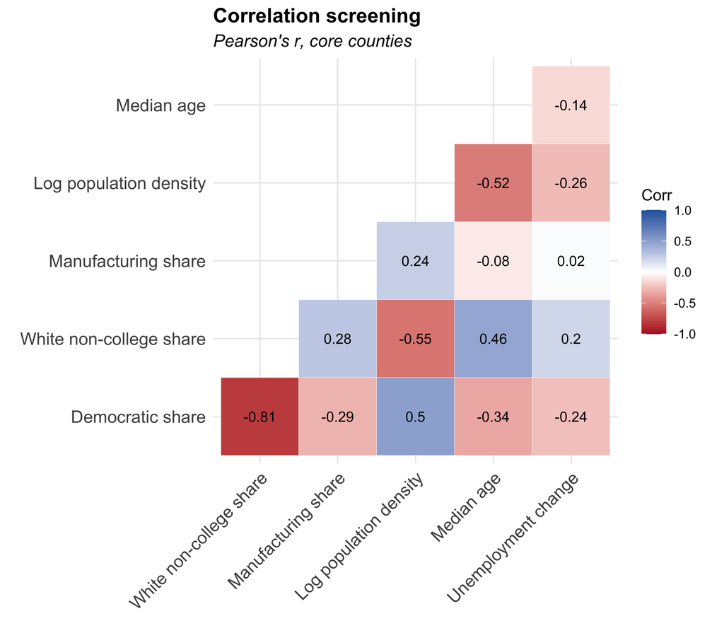

```r
# Correlations among the response variable and the five predictors
cor_vars <- c(response, predictors)
cor_mat <- midwest %>%
  st_drop_geometry() %>%
  dplyr::select(all_of(cor_vars)) %>%
  cor()

# Readable labels for the plot
dimnames(cor_mat) <- list(var_labels[cor_vars], var_labels[cor_vars])

ggcorrplot(cor_mat, type = "lower", lab = TRUE, lab_size = 3.5,
           colors = c("#b2182b", "white", "#2166ac"), outline.color = "white") +
  labs(title = "Correlation screening",
       subtitle = "Pearson's r, core counties") +
  theme(plot.title = element_text(size = 14, face = "bold"),
        plot.subtitle = element_text(size = 12, face = "italic"))
```

Figure 2: Correlation matrix of the response variable and the five predictors for the 242 core counties. Blue cells are positive correlations, red cells negative.

Every predictor is correlated with the Democratic share in the direction we expected (Table 3). The strongest by far is the white non-college share ($r =$ -0.81), followed by log population density ($r =$ 0.50). Unemployment change is the weakest ($r =$ -0.24). Among the predictors, the strongest correlation is between the log population density and the white non-college share ($r =$ -0.55). No pair comes close to the common warning level of $|r| > 0.8$.

One pattern is worth noting now, because it returns in Section 4. Median age is *negatively* correlated with the Democratic share ($r =$ -0.34), as expected. But median age is also correlated with two other predictors: older counties tend to have more white non-college adults ($r =$ 0.46) and lower densities ($r =$ -0.52). A simple correlation cannot tell us whether age itself is associated with the vote, or whether older counties simply differ in education and density. Multiple regression can differentiate between these altenative relationships.

## 3.3 Multicollinearity

Pairwise correlations can miss a subtler problem. A predictor might be nearly predictable from a *combination* of the other predictors, even if no single pair is strongly correlated. This issue is formally known as **multicollinearity**. Multicollinearity does not bias the coefficient estimates, but it inflates their standard errors. When two predictors carry the same information, the data cannot tell which one deserves the credit, so the estimates become imprecise and unstable.

The **variance inflation factor (VIF)** measures multicollinearity directly. Each predictor $j$, is regressed on all the other predictors and the $R_j^2$ of that regression is recorded:
$$\text{VIF}_j=\frac{1}{1-R_j^2}$$
If predictor $j$ is unrelated to the others, $R_j^2 = 0$ and $\text{VIF}_j = 1$. As $R_j^2$ approaches 1, the VIF grows without limit. A VIF of 4 means the variance of $\hat\beta_j$ is four times what it would be if predictor $j$ were uncorrelated with the others. Common rules of thumb treat a VIF above 5 as worth attention and above 10 as a serious problem.

Notice that the response variable does not appear anywhere in this calculation. Multicollinearity is a property of the predictors alone, so we can, and should, check it **before** fitting the model. The code below computes each VIF from its definition.

```r
# The predictors only, without the geometry
X <- midwest %>% st_drop_geometry() %>% dplyr::select(all_of(predictors))

# For each predictor: regress it on all the others, then convert that R² to a VIF
vif_table <- map_dfr(predictors, function(j) {
  others <- setdiff(predictors, j)
  r2_j <- summary(lm(reformulate(others, response = j), data = X))$r.squared
  tibble(variable = j, R2_j = r2_j, VIF = 1 / (1 - r2_j))
})

# The same VIFs from the inverse of the correlation matrix, as a check
stopifnot(isTRUE(all.equal(vif_table$VIF, unname(diag(solve(cor(X)))))))
```

| Predictor | R² with the other predictors | VIF |
| --- | --- | --- |
| White non-college share | 0.53 | 2.11 |
| Manufacturing share | 0.31 | 1.45 |
| Log population density | 0.56 | 2.27 |
| Median age | 0.41 | 1.68 |
| Unemployment change | 0.19 | 1.24 |

Table 4: Variance inflation factors for the five predictors, with the $R_j^2$ from regressing each predictor on the other four.

In the Midwest dataset, the VIFs range from 1.24 (unemployment change) to 2.27 (log population density). Even the largest VIF means that the other four predictors account for only 56 percent of the variation in log population density. All are well below threshold value of 5, so multicollinearity is not a concern and the specification can stand.

Had a VIF been large, this is the point at which we would change the specification: drop one of the overlapping predictors, combine them into an index, or accept wider standard errors knowingly. After a model is fit, `car::vif()` returns the same values directly from the fitted model object.

## 3.4 Fitting the Model

In R, `lm()` estimates the coefficients by **ordinary least squares (OLS)**. For each county, the fitted model gives a **fitted value** $\hat{y}_i$, the model’s prediction, and a **residual** $e_i = y_i - \hat{y}_i$, the part of the observed value the model does not explain. The residuals are what we use to check the model in Section 3.5.

Three details in the code below matter for later work:

- **`rownames(midwest) <- midwest$fips`** names each row by its FIPS code. Spatial regression functions use these names (`spChk = TRUE`) to confirm that the residuals and a spatial weights matrix are in the same county order, so it is good practice to set them whenever a model may later be given a spatial structure.
- **`reformulate()`** builds the formula `dem_share24 ~ white_nocollege_pct + ...` from the vector of predictor names in Section 3.1, so the predictors are written down in one place only.
- **`na.action = na.fail`** stops with an error if any value is missing. The default, `na.omit`, drops incomplete counties, which would break the match between the residuals and the map. (These data have no missing values.)

```r
# Name the rows by FIPS code so later spatial functions can check the county order
rownames(midwest) <- midwest$fips

# Build the formula from the predictors chosen in Section 3.1
model_formula <- reformulate(predictors, response = response)
model_formula
```

```
## dem_share24 ~ white_nocollege_pct + manuf_pct + log_pop_density +
##     median_age + unemp_change
```

```r
# Fit the model by ordinary least squares
ols_mw <- lm(model_formula, data = midwest, na.action = na.fail)
summary(ols_mw)
```

```
##
## Call:
## lm(formula = model_formula, data = midwest, na.action = na.fail)
##
## Residuals:
##      Min       1Q   Median       3Q      Max
## -14.5123  -3.7621  -0.8323   3.3019  17.4097
##
## Coefficients:
##                     Estimate Std. Error t value             Pr(>|t|)
## (Intercept)         75.14049    4.72816  15.892 < 0.0000000000000002 ***
## white_nocollege_pct -0.62818    0.04845 -12.965 < 0.0000000000000002 ***
## manuf_pct           -0.22824    0.07885  -2.894              0.00415 **
## log_pop_density      1.21096    0.42282   2.864              0.00456 **
## median_age           0.08746    0.08757   0.999              0.31892
## unemp_change        -0.31962    0.28973  -1.103              0.27108
## ---
## Signif. codes:  0 '***' 0.001 '**' 0.01 '*' 0.05 '.' 0.1 ' ' 1
##
## Residual standard error: 5.933 on 236 degrees of freedom
## Multiple R-squared:  0.6757, Adjusted R-squared:  0.6688
## F-statistic: 98.33 on 5 and 236 DF,  p-value: < 0.00000000000000022
```

The printout has three parts.

- **Residuals** summarizes the distribution of the residuals.
- **Coefficients** gives each estimate with its standard error, t-value, and p-value.
- **Residual Standard Error**, $R^2$, adjusted $R^2$, and the F-test.

We read the last two parts in Section 3.6 and Section 4, after checking whether the assumptions behind them hold.

## 3.5 Checking the Assumptions

OLS always produces a numerical result. Whether that result, and especially its standard errors and p-values, can be trusted depends on four assumptions about the errors, often remembered as **LINE**:

|  | Assumption | What it means | How we check it |
| --- | --- | --- | --- |
| **L** | Linearity | The response variable is a linear function of the predictors | Residuals vs. fitted values |
| **I** | Independence | The errors are unrelated to one another | **Not checked here:** requires mapping the residuals |
| **N** | Normality | The errors are normally distributed with mean zero | Histogram and Q-Q plot of residuals |
| **E** | Equal variance | The spread of the errors is the same at every fitted value | Residuals vs. fitted values; Breusch–Pagan test |

When these hold, the OLS estimates are unbiased and have the smallest variance of any linear unbiased estimator (the Gauss–Markov theorem), and the usual standard errors and p-values are valid. We also check for **influential observations**: single counties that pull the estimates toward themselves.

We cannot see the errors $\varepsilon_i$, so we check the assumptions on their estimates, the residuals. For most checks we use **standardized residuals**, which divide each residual by an estimate of its own standard deviation:
$$r_i=\frac{e_i}{s\sqrt{1-h_{ii}}}$$
where $s$ is the residual standard error and $h_{ii}$ is the county’s leverage (defined below). On this scale, about 95 percent of residuals should fall within ±2 if the errors are normal.

```r
# One row per county: the fitted value and four diagnostic quantities
diag_mw <- midwest %>%
  st_drop_geometry() %>%
  mutate(fitted   = fitted(ols_mw),
         resid    = residuals(ols_mw),   # raw residuals, in percentage points
         std_res  = rstandard(ols_mw),   # standardized residuals
         leverage = hatvalues(ols_mw),
         cooks    = cooks.distance(ols_mw))
```

### Linearity and Equal Variance

A plot of residuals against fitted values can be used to check both the linearity and equal variance assumptions. If the model is well specified, and these assumptions are met, the points form a horizontal band around zero with no pattern. Alternatively, some patterns are commonly observed:

- **A curve** suggests non-linearity: the model systematically over- or under-predicts in some range.
- **A funnel** suggests unequal variance (**heteroskedasticity**): the model is more precise for some counties than others.

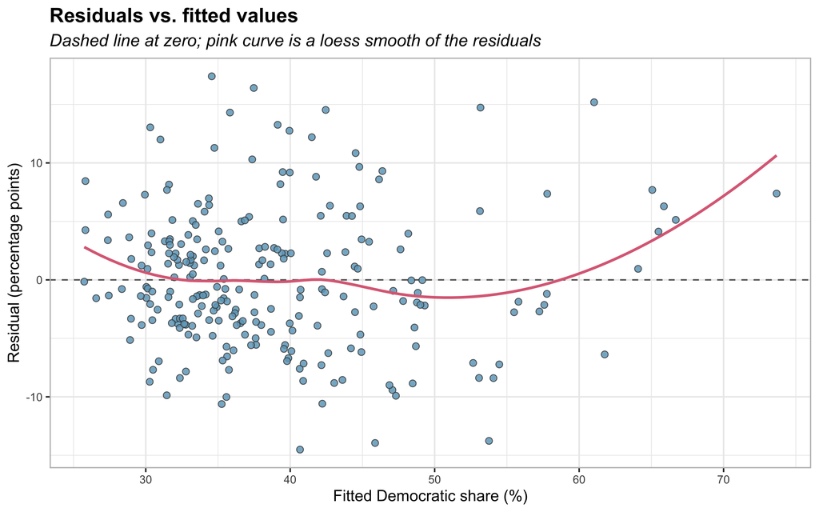

```r
ggplot(diag_mw, aes(fitted, resid)) +
  geom_hline(yintercept = 0, color = "gray40", linetype = "dashed") +
  geom_point(shape = 21, fill = "#6EA6C3", color = "gray25", size = 2, stroke = 0.4, alpha = 0.85) +
  geom_smooth(method = "loess", formula = y ~ x, se = FALSE, color = "#DC6D85", linewidth = 0.9) +
  labs(title = "Residuals vs. fitted values",
       subtitle = "Dashed line at zero; pink curve is a loess smooth of the residuals",
       x = "Fitted Democratic share (%)", y = "Residual (percentage points)") +
  themeGrid
```

Figure 3: Residuals against fitted values for the five-predictor model. The pink curve traces the average residual across the range of fitted values.

For the Midwest voting data, two departures stand out.

**Mild non-linearity at the top end.** Across most of the range, the loess curve stays within a point or two of zero, rising slightly at the lowest fitted values. Above a fitted share of about 60 percent, it bends sharply upward: the 8 counties the model expects to be most Democratic are, on average, 5.0 points *more* Democratic than predicted. Most are metropolitan and college-town counties (Dane, Washtenaw, Hennepin, Ramsey, Milwaukee), whose Democratic lean is stronger than education and density alone predict; Menominee is also among them. The exception is Oakland County, Michigan, an affluent suburban county that is *less* Democratic than predicted. The pattern points to something the model is missing in a handful of places rather than a wrong functional form for the whole region.

**Unequal variance.** The spread of the residuals widens as the fitted values rise. The standard deviation of the residuals is 4.8 points among the quarter of counties with the lowest fitted values and 6.7 points among the quarter with the highest. The **Breusch–Pagan test** formalizes this check: it regresses the squared residuals on the predictors and asks whether they explain the residuals’ size. Here, BP = 22.5 on 5 degrees of freedom, $p$ < 0.001, so we reject equal variance. Under heteroskedasticity, the coefficients are still unbiased, but the usual standard errors are not trustworthy. We return to how much this matters at the end of this section.

### Normality

A **histogram** of the standardized residuals shows their overall shape. A **Q-Q plot** is more sensitive: it plots the ordered residuals against the values a normal distribution would produce, so normal residuals fall along the diagonal line and departures in the tails stand out.

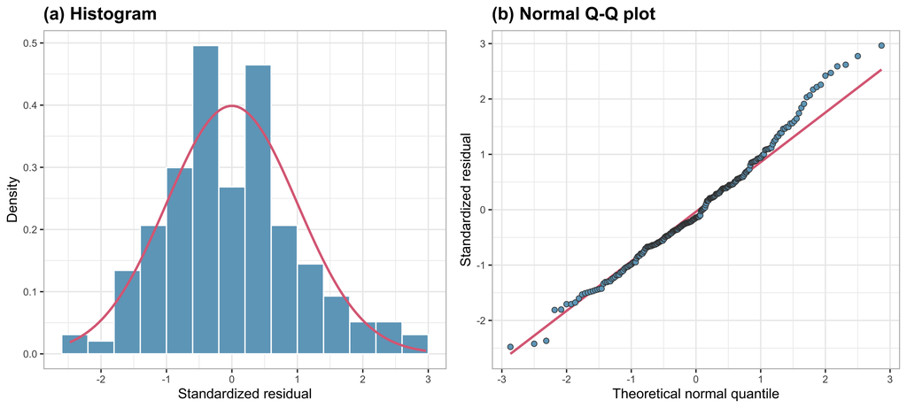

```r
# (a) Histogram of the standardized residuals with a standard normal curve for reference
p_hist <- ggplot(diag_mw, aes(std_res)) +
  geom_histogram(aes(y = after_stat(density)), binwidth = 0.4, fill = "#6EA6C3", color = "white") +
  stat_function(fun = dnorm, color = "#DC6D85", linewidth = 0.9) +
  labs(title = "(a) Histogram", x = "Standardized residual", y = "Density") +
  themeGrid

# (b) Normal Q-Q plot
p_qq <- ggplot(diag_mw, aes(sample = std_res)) +
  stat_qq_line(color = "#DC6D85", linewidth = 0.9) +
  stat_qq(shape = 21, fill = "#6EA6C3", color = "gray25", size = 1.8, stroke = 0.4) +
  labs(title = "(b) Normal Q-Q plot", x = "Theoretical normal quantile", y = "Standardized residual") +
  themeGrid

grid.arrange(p_hist, p_qq, ncol = 2)
```

Figure 4: The distribution of the standardized residuals: (a) a histogram with a standard normal curve, and (b) a normal Q-Q plot.

### Leverage and Influence

It is also important to diagnose if the regression fit is being influenced by a few outlier observations. Typically observation become outliers in two ways:

- **An unusual response**, far from the line, gives a large residual.
- **An unusual combination of predictors**, far from the other counties in predictor space, gives high **leverage**, $h_{ii}$. Leverage measures how much a county’s own value pulls its fitted value toward itself. The average leverage is always $(k+1)/n$, where $k$ is the number of predictors; values above twice the average deserve a look.

A county with both has **influence**: removing it would noticeably change the coefficients. **Cook’s distance** combines the two:
$$D_i=\frac{r_i^2}{k+1}\cdot\frac{h_{ii}}{1-h_{ii}}$$
A common screen flags counties with $D_i > 4/n$.

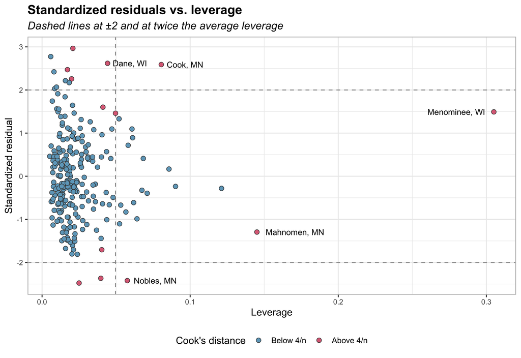

Figure 5: Standardized residuals against leverage. Pink points have a Cook’s distance above $4/n$; the five most influential counties are labeled.

| County | Democratic share | Fitted | Residual | Std. residual | Leverage | Cook’s D |
| --- | --- | --- | --- | --- | --- | --- |
| Menominee County, WI | 81.0 | 73.7 | 7.4 | 1.49 | 0.305 | 0.163 |
| Cook County, MN | 67.9 | 53.2 | 14.7 | 2.59 | 0.080 | 0.098 |
| Nobles County, MN | 31.9 | 45.9 | -13.9 | -2.42 | 0.058 | 0.060 |
| Dane County, WI | 76.2 | 61.0 | 15.2 | 2.62 | 0.044 | 0.053 |
| Mahnomen County, MN | 45.6 | 52.7 | -7.1 | -1.29 | 0.145 | 0.047 |
| Waukesha County, WI | 40.0 | 53.8 | -13.8 | -2.37 | 0.040 | 0.039 |
| Lake County, MN | 52.0 | 34.6 | 17.4 | 2.97 | 0.021 | 0.031 |
| Luce County, MI | 26.2 | 40.7 | -14.5 | -2.48 | 0.025 | 0.026 |
| Mackinac County, MI | 37.4 | 47.3 | -9.9 | -1.70 | 0.040 | 0.020 |
| Price County, WI | 34.3 | 25.8 | 8.4 | 1.46 | 0.050 | 0.019 |
| Bayfield County, WI | 55.7 | 46.4 | 9.3 | 1.60 | 0.041 | 0.018 |
| St. Louis County, MN | 57.0 | 42.5 | 14.5 | 2.47 | 0.017 | 0.018 |
| Ashland County, WI | 52.4 | 39.1 | 13.3 | 2.26 | 0.020 | 0.017 |

Table 5: The 13 counties with a Cook’s distance above $4/n$ = 0.017, in order of influence.

13 counties exceed the $4/n$ screen, and one stands out. **Menominee County, Wisconsin** has the largest Cook’s distance (0.16) despite a modest residual, because its leverage (0.31) is 12 times the average. Menominee is coterminous with the Menominee Indian Reservation: 78 percent of its residents are Native American, so its white non-college share (12 percent) is the lowest in the region, far below even the urban cores of Ann Arbor, Minneapolis, and Milwaukee. No other county combines low density with so few white non-college adults, so the fitted plane bends toward it. Refitting the model without Menominee moves the log density coefficient from 1.21 to 1.54.

The other flagged counties have large residuals instead. Dane (Madison) and Cook (on Lake Superior’s North Shore) are far *more* Democratic than predicted; Nobles (home to Worthington, a meatpacking center with a large Hispanic population) and Waukesha (an affluent, college-educated suburb of Milwaukee) are far *less*.

It is tempting to delete influential counties and refit. Resist the temptation. These counties are real places, correctly measured; they are unusual because the model leaves something out, such as Native American population, income, or a university. Influence diagnostics are most useful as **clues to omitted variables**, not as a license to discard data.

### How Much Do the Violations Matter?

The diagnostics found unequal variance, a mildly skewed upper tail, and one highly influential county. Of these, heteroskedasticity matters most for inference, because it makes the usual standard errors unreliable. One check is to recompute the standard errors with a method that does not assume equal variance. **Heteroskedasticity-consistent (robust) standard errors** estimate each coefficient’s variance from the residuals county by county, so counties with larger residuals count for more. The coefficients do not change; only their standard errors and p-values do.

```r
# Robust (HC3) standard errors: same coefficients, standard errors that allow unequal variance
robust <- lmtest::coeftest(ols_mw, vcov = car::hccm(ols_mw, type = "hc3"))

robust_compare <- tibble(variable = predictors,
                         se_ols = coef(summary(ols_mw))[predictors, "Std. Error"],
                         p_ols = coef(summary(ols_mw))[predictors, "Pr(>|t|)"],
                         se_robust = robust[predictors, "Std. Error"],
                         p_robust = robust[predictors, "Pr(>|t|)"])
```

| Predictor | SE (usual) | p (usual) | SE (robust) | p (robust) |
| --- | --- | --- | --- | --- |
| White non-college share | 0.048 | < 0.001 | 0.062 | < 0.001 |
| Manufacturing share | 0.079 | 0.004 | 0.076 | 0.003 |
| Log population density | 0.423 | 0.005 | 0.553 | 0.030 |
| Median age | 0.088 | 0.319 | 0.089 | 0.326 |
| Unemployment change | 0.290 | 0.271 | 0.332 | 0.336 |

Table 6: Usual and heteroskedasticity-robust (HC3) standard errors and p-values for the five predictors.

The conclusions hold. The same 3 predictors are significant at the 0.05 level under both methods: white non-college share, manufacturing share, log population density. The largest change is for log population density, whose standard error rises from 0.42 to 0.55 and whose p-value rises from 0.005 to 0.030: still significant, but with less margin. We can therefore read the model’s fit (Section 3.6) and its coefficients (Section 4), keeping in mind that the density estimate is less certain than the usual output suggests.

## 3.6 Model Fit

With the assumptions checked, we can read the bottom of the `summary()` output (Table 7).

```r
s <- summary(ols_mw)
fit_stats <- tibble(
  Statistic = c("Counties (n)", "R²", "Adjusted R²", "Residual standard error (points)",
                "F-statistic", "F-test p-value", "AIC"),
  Value = c(nobs(ols_mw), s$r.squared, s$adj.r.squared, sigma(ols_mw),
            s$fstatistic["value"],
            pf(s$fstatistic["value"], s$fstatistic["numdf"], s$fstatistic["dendf"], lower.tail = FALSE),
            AIC(ols_mw)))
```

| Statistic | Value |
| --- | --- |
| Counties (n) | 242 |
| R² | 0.68 |
| Adjusted R² | 0.67 |
| Residual standard error (points) | 5.93 |
| F-statistic | 98.3 |
| F-test p-value | < 0.001 |
| AIC | 1556.5 |

Table 7: Overall fit of the five-predictor model.

Let’s look at each of these summary statistics in turn.

- **$R^2$** is the share of the variation in the response variable that the model accounts for:
  $$R^2 = 1-\frac{\sum e_i^2}{\sum (y_i-\bar{y})^2}$$
  Here, the five predictors account for 68 percent of the county-to-county variation in the Democratic share. For county-level election data, that is a strong fit. “Account for” is a statement about variation, not about causes.
- **Adjusted $R^2$** penalizes each added predictor. $R^2$ never decreases when a predictor is added, even a useless one, so adjusted $R^2$ is the fairer measure when comparing models with different numbers of predictors. Here the two are nearly equal (0.68 and 0.67) because five predictors are few relative to 242 counties.
- **The residual standard error** is the typical size of a residual: the model’s predictions miss by about 5.9 percentage points. Section 3.5 showed that this is an average over unequal spreads, smaller for Republican-leaning counties and larger for Democratic-leaning ones.
- **The F-test** asks whether all five slopes are zero at once. With $p$ < 0.001, the predictors together are clearly associated with the vote. The F-test assumes equal variance, but a result this strong is not in doubt.
- **AIC** (Akaike’s information criterion) balances fit against the number of parameters: $\text{AIC} = 2p - 2\ln\mathcal{L}$, where $p$ is the number of estimated parameters and $\mathcal{L}$ the likelihood. Lower is better, but AIC has no meaning on its own; it only compares models fit to the same response variable and the same counties. We will use it to compare this model with spatial models.

How much do the other four predictors add? A model with white non-college share alone gives $R^2 =$ 0.65; the four other predictors raise it to 0.68. Most of the model’s explanatory power comes from one predictor.

# 4. Interpretation

With the model specified, fitted, and checked, we can interpret what it says. Each coefficient in Table 8 answers the same question: how does the predicted Democratic share differ between two counties that differ by one unit in this predictor but are the same on the other four? The hypotheses and expected signs from Section 3.1 tell us what to look for, the correlations from Section 3.2 tell us what a predictor looks like on its own, and the diagnostics from Section 3.5 tell us how far to trust the standard errors.

```r
# Coefficients with confidence intervals, units, the sign we expected, and the effect of a one-SD change
ci <- confint(ols_mw)
coef_tab <- tibble(variable = predictors,
                   estimate = coef(ols_mw)[predictors],
                   se = coef(summary(ols_mw))[predictors, "Std. Error"],
                   p = coef(summary(ols_mw))[predictors, "Pr(>|t|)"],
                   lower = ci[predictors, 1],
                   upper = ci[predictors, 2],
                   sd_x = sapply(X[predictors], sd)) %>%
  mutate(sd_effect = estimate * sd_x) %>%
  left_join(spec %>% dplyr::select(variable, Expected), by = "variable") %>%
  left_join(codebook %>% dplyr::select(variable, units), by = "variable")
```

| Predictor | Units | Estimate | SE | p | 95% CI | Effect of 1 SD | Sign Expected | Sign Estimated |
| --- | --- | --- | --- | --- | --- | --- | --- | --- |
| White non-college share | % | -0.628 | 0.048 | < 0.001 | [-0.72, -0.53] | -7.193 | Negative | Negative |
| Manufacturing share | % | -0.228 | 0.079 | 0.004 | [-0.38, -0.07] | -1.331 | Negative | Negative |
| Log population density | log persons/km² | 1.211 | 0.423 | 0.005 | [0.38, 2.04] | 1.650 | Positive | Positive |
| Median age | years | 0.087 | 0.088 | 0.319 | [-0.09, 0.26] | 0.495 | Negative | Positive |
| Unemployment change | percentage points | -0.320 | 0.290 | 0.271 | [-0.89, 0.25] | -0.469 | Negative | Negative |

Table 8: Coefficients of the five-predictor model. Each estimate is the change in the Democratic share, in percentage points, per one-unit increase in the predictor (in the units shown), holding the other predictors constant. The intercept, 75.14, is omitted. “Effect of 1 SD” is the estimate times the predictor’s standard deviation.

Every coefficient is read the same way: **sign**, **size in the units of the response variable per unit of the predictor**, and **holding the other predictors constant**.

**White non-college share.** A county with one percentage point more white non-college adults has a predicted Democratic share 0.63 points lower, holding the other four predictors constant. Scaled to a more meaningful difference, 10 percentage points more white non-college adults predicts a share 6.3 points lower. The coefficient is smaller than the slope in a model with white non-college share alone (-0.73) because part of what looked like the effect of education there was density and industry, which the five-predictor model now holds constant.

**Manufacturing share.** One percentage point more manufacturing employment predicts a share 0.23 points lower, consistent with the deindustrialization hypothesis.

**Log population density.** Because density is logged, a one-unit increase in $\ln(\text{density})$ means multiplying density by $e \approx 2.72$, which predicts a share 1.21 points higher. A more natural change is a doubling. The predicted change for any ratio of densities is $\hat\beta \times \ln(\text{ratio})$, so doubling density predicts a share 0.84 points higher, and a tenfold increase predicts 2.8 points higher.

**Median age.** Here the multiple regression contradicts the correlation in Section 3.2. On its own, median age is *negatively* correlated with the Democratic share ($r =$ -0.34). In the model, its coefficient is *positive* (0.09) and not significant ($p =$ 0.32; 95% CI from -0.09 to 0.26). The negative correlation arose because older counties are also whiter, less college-educated, and less dense. Once those differences are held constant, little association with age remains. This is what “holding the other predictors constant” buys us, and why a simple correlation can mislead.

**Unemployment change.** The coefficient is negative, as expected, but not significant ($p =$ 0.27). A county whose unemployment recovered one percentage point *less* from 2020 to 2023 has a predicted share 0.32 points lower. Not significant does not mean no effect: the 95% confidence interval runs from -0.89 to 0.25, which includes zero but also includes meaningful negative values. These data cannot distinguish the association from zero.

Looking at the estimated coefficients collectively, we cannot rank the predictors by the size of their coefficients, because they are in different units: percentage points, log persons per km², and years. The “Effect of 1 SD” column in Table 8 puts them on a common scale by asking what a typical difference in each predictor (one standard deviation) does to the prediction. On that scale, white non-college share dominates (-7.2 points), followed by log density (1.6) and manufacturing (-1.3).

We should also compare these estiamtes with our original expectations. 4 of the 5 coefficients have the sign we expected in Table 3, and three of those are significant. Median age has the opposite sign, but its interval includes zero, so the data neither support nor clearly contradict the hypothesis once education and density are accounted for.

Finally, these are associations across counties, not causal effects: the model does not show that changing a county’s manufacturing share would change its vote. Nor do they describe individual voters. That counties with more white non-college adults vote less Democratic does not mean that white non-college *individuals* do, or by how much. Drawing that conclusion from county data is the **ecological fallacy**.

**Considerations**

Section 3.5 found that the model under-predicts the most Democratic metropolitan and college-town counties, and Table 5 lists counties whose large residuals point to something the model leaves out.

1. Choose two of the counties in Table 5. For each, propose a variable from Table 1 (or one not in the data) that might explain its residual, and state the sign you would expect.
2. Would adding that variable change the interpretation of the white non-college coefficient? Why might it?
3. So far, we have treated the 242 residuals as a list. Look again at where the flagged counties are on the map in Figure 1. What would it mean for the independence assumption if counties with large positive residuals sat next to one another?

### Declaration of Generative AI and AI-Assisted Technologies

The author used Anthropic’s Claude (Opus 5.5) when developing this demonstration. A connection to RStudio through the ClaudeR package was used to draft and debug the R code. The author subsequently reviewed and edited all of that output and takes full responsibility for the content.